# **Trabajo Práctico N°1**

El presente trabajo práctico fue realizado por los alumnos:

- Anarella Nicoletta (Padrón 94551)
- Bruno Grassano (Padrón 103855)
- Ignacio Javier Mermet (Padrón 98153)
- Joaquin Gomez (Padrón 103735)

# Ejercicio 1

Sobre el generador de números al azar propuesto en el [paper asignado](https://drive.google.com/file/d/196pKnZFBc_sG6ceFNk64q8vn6BdQiwPx/view), se pide:

- Implementarlo en función de lo especificado en el documento.
- Modificarlo (si aplica) para obtener números al azar entre 0 y 1
- Realizar los gráficos que considere adecuados para mostrar las distribuciones de números al azar generados en ambos casos.

La implementación de los generadores se puede ver en el módulo `generators.py`. En este notebook resolveremos el último punto.

Se espera que los números generados estén justamente uniformemente distribuidos.

```
class LXM(RandomGenerator):
    """LXM random number generator."""

    def __init__(
        self,
        M: np.uint64 = np.uint64(0xD1342543DE82EF95),
        w: np.uint64 = np.uint64(32),
        a: np.uint64 = np.uint64(1664525),
    ):
        if (a % 2) != 1:
            raise ValueError("a debe ser impar")

        self.w = w
        self.LCG = GCL(multiplicador=M, incremento=a)
        self.XBG = XBG()
```

```
def generar(self, uniforme: bool = True) -> Union[np.float64, np.uint64]:
        """Generar un número aleatorio."""

        def high_order_bits(s, w):
            """Get w highest order bits from s."""
            return np.right_shift(s, np.uint64(s.nbytes * 8 - w))

        s = self.LCG.generar(uniforme=False)
        t = self.XBG.generar(uniforme=False)

        z = self._mix(
            self._combine(high_order_bits(s, self.w), high_order_bits(t, self.w))
        )
        return z / np.iinfo(np.uint64).max
```

```
def _combine(self, *args):  # pylint:disable=no-self-use
        """Combination operation for the XBG and LCG numbers."""
        z = np.sum(args)
        return z
```

```
def _mix(self, z):  # pylint:disable=no-self-use
        """Mix operation."""
        z = np.multiply(
            np.bitwise_xor(z, np.right_shift(z, np.uint64(32))),
            np.uint64(0xDABA0B6EB09322E3),
        )
        z = np.multiply(
            np.bitwise_xor(z, np.right_shift(z, np.uint64(32))),
            np.uint64(0xDABA0B6EB09322E3),
        )
        z = np.bitwise_xor(z, np.right_shift(z, np.uint64(32)))
        return z
```

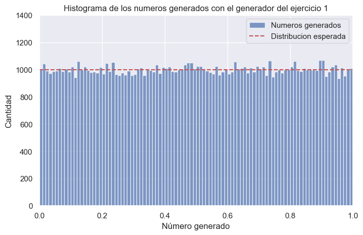

```python
ejercicio1(LXM())
```

Viendo el gráfico podemos ver que parece que se cumple, para analizar esto con más detalle vemos los tests.

# Ejercicio 2

Para cada una de las 2 versiones del generador implementado en el ejercicio 1:

- Proponer, y realizar, al menos 2 tests para evaluar su comportamiento.
- Evaluar e interpretar los resultados de cada uno para distintos tamaños de muestras.

## Test de gap

```
Estadistico: 26.78
límit superior: 44.99
El test acepta la hipotesis nula.
```

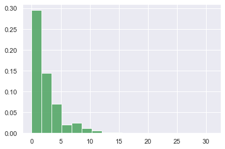

```python
ejercicio2TestGap(LXM())
```

## Test chi2

```python
ejercicio2TestChi2(LXM())
```

```
Frecuencias:  [9971, 9997, 9863, 9952, 10148, 9962, 10044, 9953, 9971]
Estadistico: 45141.51
Limite superior: 13.28
El test rechaza la hipótesis nula
```

Como se puede observar en la ejecución de este test, se rechaza la hipótesis nula.

## Tests espectrales

Para finalizar, haremos tests espectrales para visualizar si existen patrones en los numeros generados

```
Dimensiones (filas,cols) = (5000, 2)
```

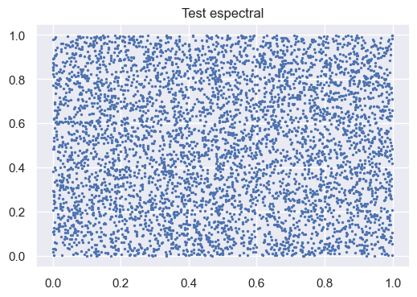

```python
ejercicio2TestEspectralvisualizacion2D(LXM())
```

Se puede visualizar que no hay patrones ni en el centro de la imagen ni sobre las esquinas. Nos fijamos en 3 dimensiones para corroborar

```
Dimensiones (filas,cols) = (3334, 3)
```

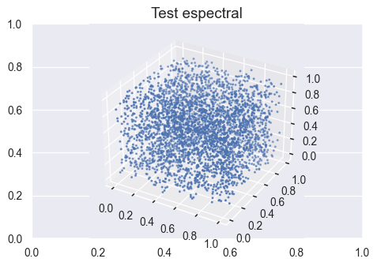

```python
ejercicio2TestEspectralvisualizacion3D(LXM())
```

Podemos confirmar que tampoco se observan patrones en 3 dimensiones.

# Ejercicio 3

[figure not shown]

En primer lugar utilizaremos el generador de números al azar con distribución uniforme, provisto por la librería numpy del lenguaje Python.

```
Factor de rendimiento: 7834/10000 (78.34%)
```

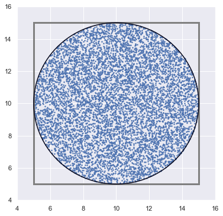

```python
plot_circle_np()
```

El alto rendimiento de este método se debe principalmente a la selección de los límites del sector donde se generan los puntos aleatorios.

A continuación repetiremos el procedimiento, pero esta vez usando el generador de números al azar implementado en el ejercicio 1.

```
Factor de rendimiento: 7765/10000 (77.65%)
```

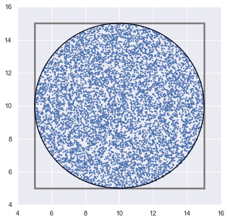

```python
ejercicio3(LXM())
```

Los resultados son muy similares a los obtenidos previamente.

# **Ejercicio 4**

[figure not shown]

Definimos la función de densidad de probabilidad asociada a la gráfica del enunciado como

$$ f(x) = \left\{ \begin{array}\\ \frac{1}{15}\ x - \frac{1}{15} & \mbox{si } \ 1\leq x<4\\ -\frac{2}{45}\ x + \frac{17}{45} & \mbox{si } \ 4\leq x<6\\ \frac{1}{9}\ & \mbox{si } \ 6\leq x<9\\ -\frac{1}{9}\ x + \frac{10}{9} & \mbox{si } \ 9\leq x<10\\ 0 & \mbox{en cualquier otro caso} \end{array} \right. $$

Verificamos que se trata de una función de densidad de probabilidad válida.

$$\int_{1}^{10} f(x)dx = \int_{1}^{4} (\frac{1}{15}\ x - \frac{1}{15} ) dx + \int_{4}^{6} (-\frac{2}{45}\ x + \frac{17}{45} ) dx + \int_{6}^{9} \frac{1}{9}\ dx + \int_{9}^{10} (-\frac{1}{9}\ x + \frac{10}{9} ) dx$$$$= \frac{1}{15}\ \int_{1}^{4} (x - 1) dx + \frac{1}{45}\ \int_{4}^{6} (-2 x + 17) dx + \int_{6}^{9} \frac{1}{9}\ dx + \frac{1}{9}\ \int_{9}^{10} (-x + 10) dx$$$$= \frac{1}{15}\ (\frac{x^2}{2}\ -x) \Big|_1^4\ + \frac{1}{45}\ (-x^2+17x) \Big|_4^6\ + \frac{1}{9}\ (x) \Big|_6^9\ + \frac{1}{9}\ (-\frac{x^2}{2}\ +10x) \Big|_9^{10}$$$$= \frac{1}{15}\ * \frac{9}{2}\ + \frac{1}{45}\ *14 + \frac{1}{3}\ + \frac{1}{9}\ *\frac{1}{2}$$$$\int_{1}^{10} f(x)dx = 1$$

Procedemos a calcular la función de probabilidad acumulada para la variable aleatoria X. Para ello integramos $f(x)$ en los distintos intervalos.

$$\int_{1}^{x} (\frac{1}{15}\ t - \frac{1}{15} ) dt=\frac{1}{15}\ (\frac{t^2}{2}\ -t) \Big|_1^x\ =\frac{1}{15}\ (\frac{x^2}{2}\ -x-\frac{1}{2}\ +1)=\frac{1}{15}\ (\frac{x^2}{2}\ -x+\frac{1}{2}\ )$$$$\int_{4}^{x} (-\frac{2}{45}\ t + \frac{17}{45} ) dt+\frac{3}{10}=\frac{1}{45}\ (-t^2+17t) \Big|_4^x\ +\frac{3}{10}=\frac{1}{45}\ (-x^2+17x+4^2-17*4)+\frac{3}{10}=\frac{1}{45}\ (-x^2+17x-52)+\frac{3}{10}$$$$\int_{6}^{x} (\frac{1}{9}) dt+\frac{11}{18}=\frac{1}{9}\ (t) \Big|_6^x\ +\frac{11}{18}=\frac{1}{9}\ (x-6)+\frac{11}{18}$$$$\int_{9}^{x} (-\frac{1}{9}\ t + \frac{10}{9}) dt+\frac{17}{18}=\frac{1}{9}\ (-\frac{t^2}{2}\ +10t) \Big|_9^{x}+\frac{17}{18}=\frac{1}{9}\ (-\frac{x^2}{2}\ +10x+\frac{81}{2}\ -90) +\frac{17}{18}$$

$$ F_X(x) = \left\{ \begin{array}\\ 0 & \mbox{si } \ x<1\\ \frac{1}{30}\ x^2 -\frac{1}{15}\ x+\frac{1}{30}\ & \mbox{si } \ 1\leq x<4\\ -\frac{1}{45}\ x^2+\frac{17}{45}\ x-\frac{77}{90} & \mbox{si } \ 4\leq x<6\\ \frac{1}{9}\ x-\frac{1}{18}\ & \mbox{si } \ 6\leq x<9\\ -\frac{1}{18}\ x^2 +\frac{10}{9}\ x-\frac{41}{9}\ & \mbox{si } \ 9\leq x<10\\ 1 & \mbox{si } \ 10\leq x \end{array} \right. $$

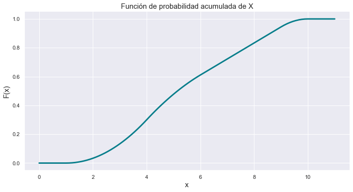

```python
plot_acumulada()
```

Para invertir $F_X(x)$ conviene expresar cada uno de los tramos cuadráticos utilizando la expresión canónica.

$$ F^{-1}_X(u) = \left\{ \begin{array}\\ 1 + \sqrt{30u} & \mbox{si } \ 0\leq u<\frac{3}{10}\\ \frac{17}{2}\ - \sqrt{-45u + \frac{135}{4}\ } & \mbox{si } \ \frac{3}{10}\ \leq u<\frac{11}{18}\\ 9u+\frac{1}{2}\ & \mbox{si } \ \frac{11}{18}\ \leq u<\frac{17}{18}\\ 10-\sqrt{-18(u-1)} & \mbox{si } \ \frac{17}{18}\ \leq u\leq1 \end{array} \right. $$

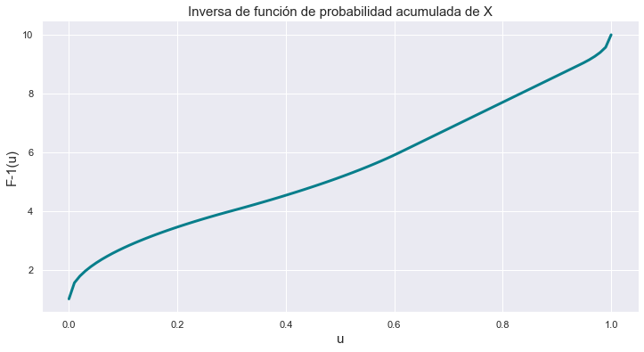

```python
plot_inversa()
```

Utilizando la función inversa, vamos a generar números aleatorios que respeten la distribución analizada. Como generador de números aleatorios con densidad uniforme tendremos el LXM que desarrollamos en el ejercicio 1. Y es justamente a esa muestra de números aleatorios que le vamos a aplicar la función inversa acumulativa.

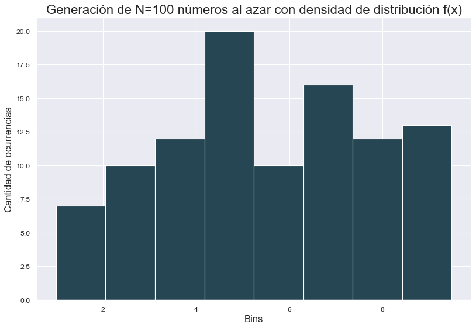

```python
ejercicio4(LXM(), 100)
```

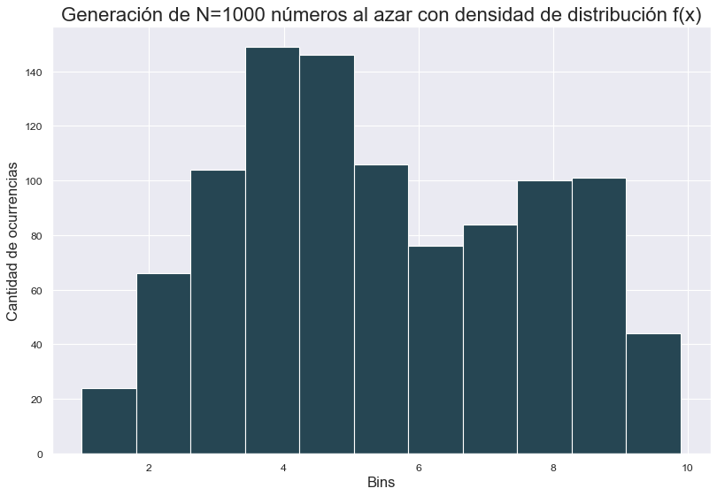

```python
ejercicio4(LXM(), 1000)
```

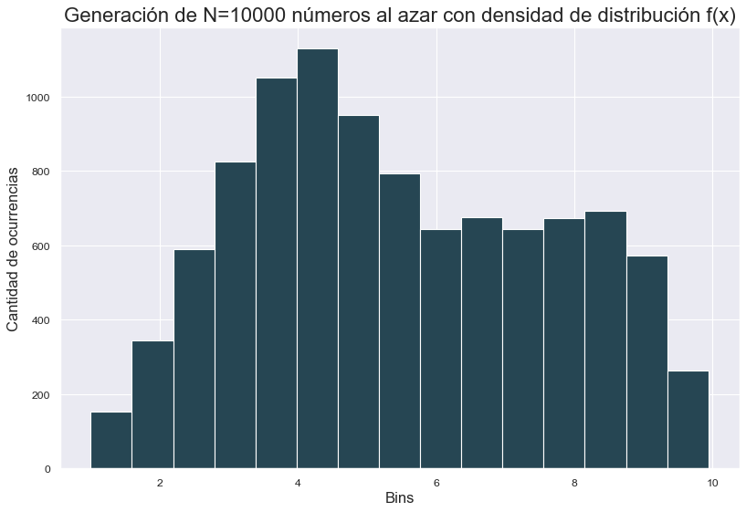

```python
ejercicio4(LXM(), 10_000)
```

# Ejercicio 5

Utilizando el generador implementado en el ejercicio 1:

- Implementar un método para generar variables aleatorias con distribución normal con media 15 y desvío 3.
- Graficar la distribución que siguen los números pseudo aleatorios generados.
- Realizar, al menos, 2 tests de los explicados en la materia para verificar si los números generados siguen la distribución pedida (evalué los resultados para distintos tamaños de muestra).

Empezamos implementando el método para generar las variables aleatorias. Para obtener la normal usamos el método de aceptación-rechazo, es decir, si se obtiene un valor dentro del area esperada, es aceptado, sino, se rechaza.

Una particularidad a tener en cuenta, es que no se puede generar una normal entera debido al rango de la exponencial, por lo que según un nuevo valor random obtenido determinamos de que lado de la normal iría.

```python
def funcionNormal(media, desvio, N, generador):
    c = np.sqrt(2 * np.exp(1) / pi)
    tExponenciales = np.random.exponential(size = N)

    zNormal = []
    for i in range(N):
        uniforme = generador.generar()
        if uniforme < probabilidadAceptar(tExponenciales[i],c):
            probabilidadSigno = generador.generar()
            if probabilidadSigno < 0.5:
                zNormal.append( tExponenciales[i] * desvio + media)
            else:
                zNormal.append( - tExponenciales[i] * desvio + media)


    return zNormal
```

```python
vNormal = funcionNormal(15,3,100000, LXM())
```

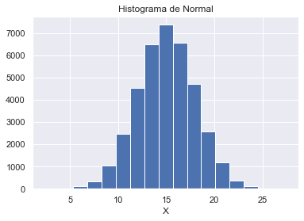

```python
plt.hist( vNormal, 'sturges')
plt.title('Histograma de Normal')
plt.xlabel('X')
plt.show()
```

```python
print('Media: ', np.mean(vNormal))
print('Desvio: ', np.std(vNormal))
```

```
Media:  14.998433918258295
Desvio:  3.0020981360214205
```

Podemos ver que los valores obtenidos de media y desvio son cercanos a los buscados.

Vemos de realizar los tests para ver si se sigue la distribución pedida.

Probamos primero aplicando el test de Kolmogorov Smirnov. Este test compara dos distribuciones de probabilidad acumulada, una se asigna a la hipótesis nula y la otra es generada de forma empírica.

Como nivel de significación $\alpha$ vamos a usar 0,05

Probamos el test para distintas muestras.

```python
ejercicio5TestKolmogorovSmirnov(LXM(), 1000)
```

```
Muestras: 1000
K obtenido = 1.144258804924369
K aceptación = 0.06903617983899596
Rechazo H0
```

```python
ejercicio5TestKolmogorovSmirnov(LXM(), 10_000)
```

```
Muestras: 10000
K obtenido = 0.7065623719698082
K aceptación = 0.021953461281922056
Rechazo H0
```

```python
ejercicio5TestKolmogorovSmirnov(LXM(), 100_000)
```

```
Muestras: 100000
K obtenido = 0.5740027002372637
K aceptación = 0.00697876938842254
Rechazo H0
```

```python
ejercicio5TestAnderson(LXM(), 1000)
```

```
Muestras: 1000
Estadístico: 0.805
Nivel de significancia: 0.150 -- Umbral: 0.570
Los datos no son normales, se rechaza H0
Nivel de significancia: 0.100 -- Umbral: 0.649
Los datos no son normales, se rechaza H0
Nivel de significancia: 0.050 -- Umbral: 0.779
Los datos no son normales, se rechaza H0
Nivel de significancia: 0.025 -- Umbral: 0.908
Los datos son normales, no se puede rechazar H0
Nivel de significancia: 0.010 -- Umbral: 1.081
Los datos son normales, no se puede rechazar H0
```

```python
ejercicio5TestAnderson(LXM(), 10_000)
```

```
Muestras: 10000
Estadístico: 0.417
Nivel de significancia: 0.150 -- Umbral: 0.575
Los datos son normales, no se puede rechazar H0
Nivel de significancia: 0.100 -- Umbral: 0.655
Los datos son normales, no se puede rechazar H0
Nivel de significancia: 0.050 -- Umbral: 0.786
Los datos son normales, no se puede rechazar H0
Nivel de significancia: 0.025 -- Umbral: 0.917
Los datos son normales, no se puede rechazar H0
Nivel de significancia: 0.010 -- Umbral: 1.091
Los datos son normales, no se puede rechazar H0
```

```python
ejercicio5TestAnderson(LXM(), 100_000)
```

```
Muestras: 100000
Estadístico: 0.239
Nivel de significancia: 0.150 -- Umbral: 0.576
Los datos son normales, no se puede rechazar H0
Nivel de significancia: 0.100 -- Umbral: 0.656
Los datos son normales, no se puede rechazar H0
Nivel de significancia: 0.050 -- Umbral: 0.787
Los datos son normales, no se puede rechazar H0
Nivel de significancia: 0.025 -- Umbral: 0.918
Los datos son normales, no se puede rechazar H0
Nivel de significancia: 0.010 -- Umbral: 1.092
Los datos son normales, no se puede rechazar H0
```

Vemos ahora con el test de Shapiro Wilk. Este test determina la normalidad de los datos.

- $H_0$: La muestra sigue la distribución probada.
- $H_1$: La muestra no sigue la distribución probada.

```python
ejercicio5TestShapiroWilk(LXM(), 1000)
```

```
Muestras: 1000
Estadístico: 0.997
p valor: 0.617208
No se puede rechazar H0
```

```python
ejercicio5TestShapiroWilk(LXM(), 10000)
```

```
Muestras: 10000
Estadístico: 0.999
p valor: 0.421801
No se puede rechazar H0
```

```python
ejercicio5TestShapiroWilk(LXM(), 100000)
```

```
Muestras: 100000
Estadístico: 1.000
p valor: 0.902605
No se puede rechazar H0
```

# Ejercicio 6

Se propone simular el desplazamiento de partículas sobre un plano utilizando un modelo basado en agentes, en el cual el desplazamiento se modela como random walking. Se considera una población de N partículas (utilizar distintos valor de N) distribuidos uniformemente sobre un área que se puede discretizar como una grilla de de 100 x 100.

Considerar:

- El movimiento de las partículas es equiprobable en las direcciones permitidas. En zonas distintas a los bordes, este movimiento será posible en 4 direcciones.
- En los límites de la zona planteada, las partículas sólo pueden moverse en las direcciones permitidas.
- Si más de una partícula, en el mismo instante de tiempo, intenta ocupar la misma posición, sólo una de ellas la ocupará, y el resto deberá volver a elegir dirección de desplazamiento. Si luego de 2 intentos consecutivos por moverse, la partícula no logra hacerlo, mantiene su lugar durante ese instante de tiempo.
- El orden en el cual se mueven las partículas debe elegirse al azar, en cada instante de tiempo, siguiendo una distribución uniforme.
- Existen los siguientes tipos de partículas, las cuales no reaccionan entre sí.

| Tipo | % | Características |
| --- | --- | --- |
| A | 70 | 1 celda por instante de tiempo |
| B | 25 | 1 celda cada 2 instantes de tiempo |
| C | 5 | 1 cada cada 4 instantes de tiempo |

Se pide:

- Utilizar el generador de números al azar implementado en el ejercicio 1.
- Una animación de la situación planteada
- Dividir el área en 2 zonas de igual dimensión, y graficar la evolución de la densidad de partículas de cada tipo en cada una de ellas.

```python
Video("images/video1.mp4")
```

[video not shown]

```python
Video("images/video2.mp4")
```

[video not shown]

```python
Video("images/video3.mp4")
```

[video not shown]

# Ejercicio opcional

Comparar los resultados obtenidos en los ejercicios 1 a 5 utilizando el generador de números al azar propuesto en el paper asignado, con los resultados que se obtendrían con un Generador Congruencial Lineal de módulo 2^32, multiplicador 1013904223, incremento de 1664525 y semilla igual a la parte entera del promedio de los números de padrón de los integrantes del grupo.

## Ejercicio 1

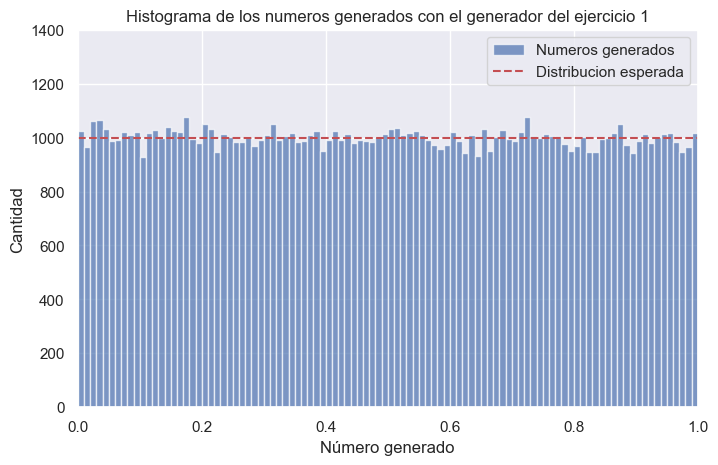

```python
ejercicio1(GCL())
```

## Ejercicio 2

```
Estadistico: 66.61
límit superior: 54.57
El test rechaza la hipótesis nula
```

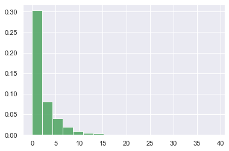

```python
ejercicio2TestGap(GCL())
```

```python
ejercicio2TestChi2(GCL())
```

```
Frecuencias:  [10175, 10107, 9975, 10030, 9978, 10028, 9905, 10038, 9921]
Estadistico: 44846.08
Limite superior: 13.28
El test rechaza la hipótesis nula
```

```
Dimensiones (filas,cols) = (5000, 2)
```

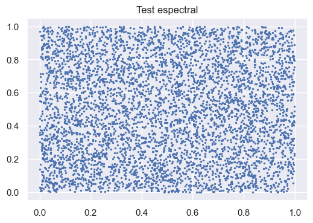

```python
ejercicio2TestEspectralvisualizacion2D(GCL())
```

```
Dimensiones (filas,cols) = (3334, 3)
```

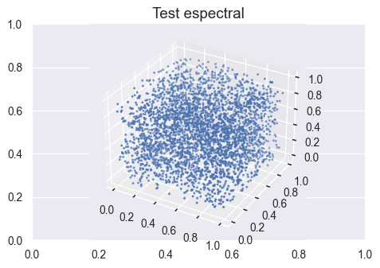

```python
ejercicio2TestEspectralvisualizacion3D(GCL())
```

## Ejercicio 3

```
Factor de rendimiento: 7819/10000 (78.19%)
```

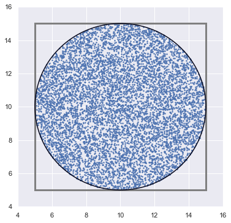

```python
ejercicio3(GCL())
```

Se puede observar que se genera con un rendimiento muy similar al de LXM. La diferencia es de menos del 1% en el rendimiento

## Ejercicio 4

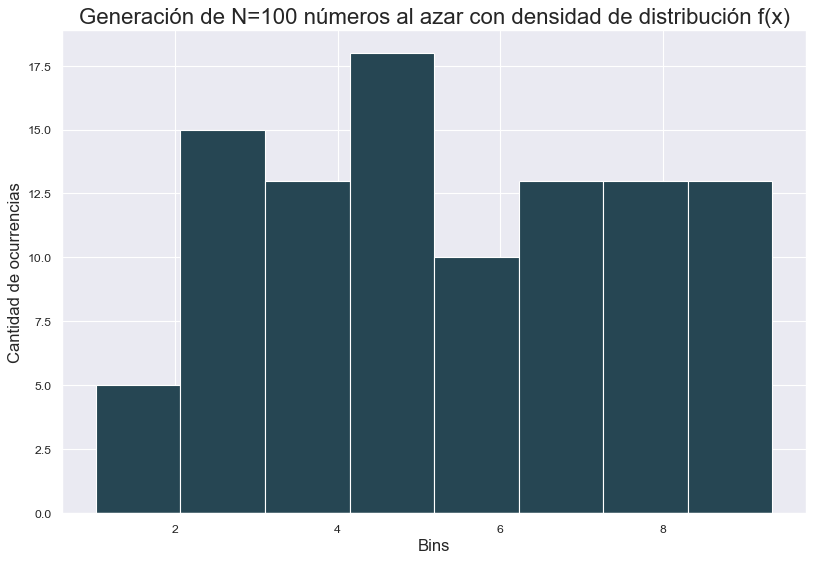

```python
ejercicio4(GCL(), 100)
```

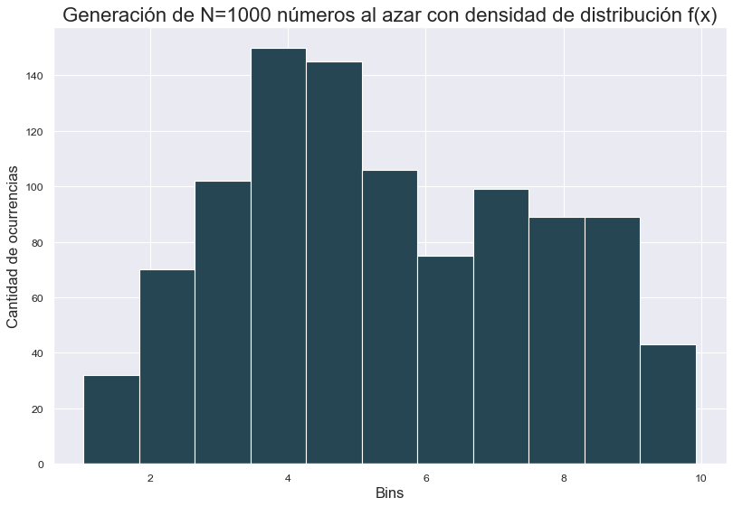

```python
ejercicio4(GCL(), 1000)
```

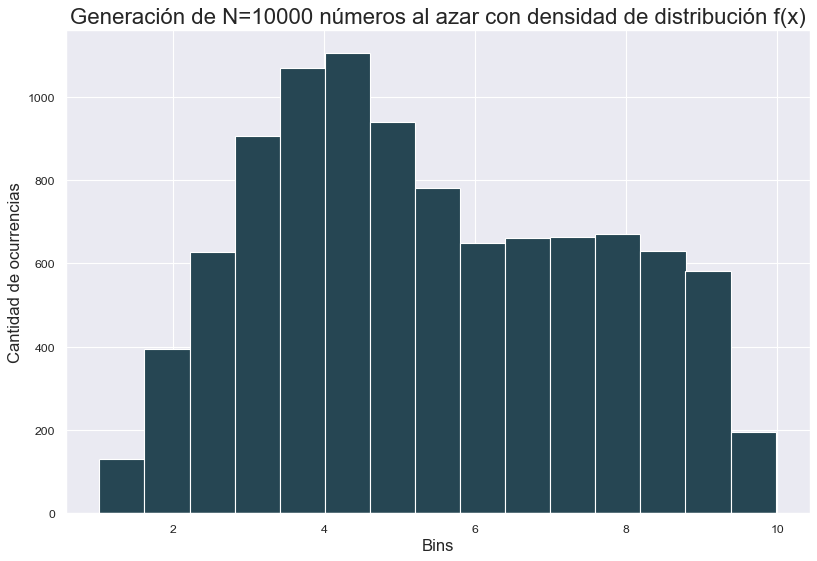

```python
ejercicio4(GCL(), 10000)
```

En este ejercicio, los histogramas se ven bastante similares salvo en el caso de N=100

## Ejercicio 5

```python
ejercicio5TestKolmogorovSmirnov(GCL(), 100)
```

```
Muestras: 100
K obtenido = 1.2652175283277283
K aceptación = 0.2364151284100073
Rechazo H0
```

```python
ejercicio5TestKolmogorovSmirnov(GCL(), 1000)
```

```
Muestras: 1000
K obtenido = 0.7521620878418961
K aceptación = 0.06885848023967459
Rechazo H0
```

```python
ejercicio5TestKolmogorovSmirnov(GCL(), 1000)
```

```
Muestras: 1000
K obtenido = 0.5449403737012231
K aceptación = 0.06842016591769931
Rechazo H0
```

Para el test de Kolmogorov, no se ven diferencias

```python
ejercicio5TestAnderson(GCL(), 100)
```

```
Muestras: 100
Estadístico: 0.456
Nivel de significancia: 0.150 -- Umbral: 0.526
Los datos son normales, no se puede rechazar H0
Nivel de significancia: 0.100 -- Umbral: 0.599
Los datos son normales, no se puede rechazar H0
Nivel de significancia: 0.050 -- Umbral: 0.718
Los datos son normales, no se puede rechazar H0
Nivel de significancia: 0.025 -- Umbral: 0.838
Los datos son normales, no se puede rechazar H0
Nivel de significancia: 0.010 -- Umbral: 0.996
Los datos son normales, no se puede rechazar H0
```

```python
ejercicio5TestAnderson(GCL(), 1000)
```

```
Muestras: 1000
Estadístico: 0.285
Nivel de significancia: 0.150 -- Umbral: 0.570
Los datos son normales, no se puede rechazar H0
Nivel de significancia: 0.100 -- Umbral: 0.649
Los datos son normales, no se puede rechazar H0
Nivel de significancia: 0.050 -- Umbral: 0.779
Los datos son normales, no se puede rechazar H0
Nivel de significancia: 0.025 -- Umbral: 0.909
Los datos son normales, no se puede rechazar H0
Nivel de significancia: 0.010 -- Umbral: 1.081
Los datos son normales, no se puede rechazar H0
```

```python
ejercicio5TestAnderson(GCL(), 10000)
```

```
Muestras: 10000
Estadístico: 0.189
Nivel de significancia: 0.150 -- Umbral: 0.575
Los datos son normales, no se puede rechazar H0
Nivel de significancia: 0.100 -- Umbral: 0.655
Los datos son normales, no se puede rechazar H0
Nivel de significancia: 0.050 -- Umbral: 0.786
Los datos son normales, no se puede rechazar H0
Nivel de significancia: 0.025 -- Umbral: 0.917
Los datos son normales, no se puede rechazar H0
Nivel de significancia: 0.010 -- Umbral: 1.091
Los datos son normales, no se puede rechazar H0
```

```python
ejercicio5TestShapiroWilk(GCL(), 100)
```

```
Muestras: 100
Estadístico: 0.978
p valor: 0.694088
No se puede rechazar H0
```

```python
ejercicio5TestShapiroWilk(GCL(), 1000)
```

```
Muestras: 1000
Estadístico: 0.994
p valor: 0.115787
No se puede rechazar H0
```

```python
ejercicio5TestShapiroWilk(GCL(), 10000)
```

```
Muestras: 10000
Estadístico: 0.999
p valor: 0.152095
No se puede rechazar H0
```

Para el test de ShapiroWilk, tampoco se ven diferencias

## Conclusión del ejercicio opcional

Se puede observar que los resultados de utilizar LXM y el generador congruencial lineal son bastante similares. Esto creemos que se debe a que LXM se basa en el generador congruencial lineal por lo tanto tiene sentido que tengan resultados parecidos.